# Gage Linearity and Bias Study

Will Kramlinger

## Problem

A co-worker had developed **two portable test machines** (*m1, m2*) meant to measure the same property as an in-house system, the **Reference** (*ref*) system. The absolute values of the measurements between machines were quickly found to differ significantly when testing with the same sample.

Two models, one for each machine, were desired to predict *ref* measurements based on the readings of each of *m1* and *m2*. Desired accuracy for each model was within 10% of the *ref* value.

## Data

Towards this end, an experiment was designed that consisted of testing 10 different samples using each of the three machines. The samples themselves consisted of two subsets: 5 containing a prototype material and expected to give lower values (samples A and B), and 5 without the prototype material and expected to give higher values (samples C and D). The original data set is shown in Table 1 below.

```r
rm(list = ls())

library(knitr)
library(kableExtra)
library(ggplot2)

df <- read.csv(file = "dummydata.csv")
df <- df[ , -c(5:7)]
colnames(df)[1:4] <- c("sample", "ref", "m1", "m2")

rownames(df) <- df$sample
df <- df[ , -1]

df %>%
  kable(align = "l") %>%
  kable_styling(bootstrap_options = c("striped", "hover", "condensed"),
                full_width = TRUE, font_size = 12, position = "center") %>%
  scroll_box(width = "100%", height = "330px")
```

|  | ref | m1 | m2 |
| --- | --- | --- | --- |
| A1 | 1.568 | 1.98 | 1.87 |
| A2 | 1.591 | 2.08 | 1.66 |
| A3 | 1.545 | 2.17 | 1.79 |
| B1 | 1.488 | 1.95 | 1.67 |
| B2 | 1.480 | 2.15 | 1.81 |
| C1 | 2.368 | 2.52 | 2.14 |
| C2 | 2.169 | 2.48 | 2.07 |
| D1 | 1.592 | 2.36 | 2.04 |
| D2 | 1.602 | 2.53 | 2.10 |
| D3 | 1.690 | 2.44 | 2.06 |

*Table 1: Original data set comprising 10 observations (samples), each measured across 3 machines (predictors).*

Upon exploratory data analysis (EDA), a problem with the data was observed. Namely, the *ref* measurements for samples D1 - D3 did not produce the higher values which were fully expected based on a significant amount of previous experiments. Via physical intuition and past experience, these outlier values were attributed to faulty connections in the *ref* measurement system. **Thus, the decision was made to remove the ref values for samples D1 - D3 from the data set.**

The resulting data set, used for all subsequent analysis, is found as Table 2.

```r
df[8:10, 1] <- NA
df %>%
  kable(align = "l") %>%
  kable_styling(bootstrap_options = c("striped", "hover", "condensed"),
                full_width = TRUE, font_size = 12, position = "center") %>%
  scroll_box(width = "100%", height = "330px")
```

|  | ref | m1 | m2 |
| --- | --- | --- | --- |
| A1 | 1.568 | 1.98 | 1.87 |
| A2 | 1.591 | 2.08 | 1.66 |
| A3 | 1.545 | 2.17 | 1.79 |
| B1 | 1.488 | 1.95 | 1.67 |
| B2 | 1.480 | 2.15 | 1.81 |
| C1 | 2.368 | 2.52 | 2.14 |
| C2 | 2.169 | 2.48 | 2.07 |
| D1 | NA | 2.36 | 2.04 |
| D2 | NA | 2.53 | 2.10 |
| D3 | NA | 2.44 | 2.06 |

*Table 2: Data set used for analysis, which includes the omission of 3 ref values.*

## OLS Regression

Two ordinary least squares (OLS) regression models were generated: one for the relationship between *ref* and *m1*, and one for *ref* and *m2*. The regression output of both models can be found in Table 3.

```r
attach(df)

load(file = "tabler_lm_slr.Rda")

m1.model <- lm(ref ~ m1)
m1.model.table <- tabler.lm.slr(m1.model)
m1.model.table %>%
  kable(align = "l") %>%
  kable_styling(bootstrap_options = c("striped", "hover", "condensed"),
                full_width = TRUE, font_size = 12, position = "center") %>%
  scroll_box(width = "100%", height = "160px")
```

|  | Coefficient | Std. Error | t-stat | P-value | VIF |
| --- | --- | --- | --- | --- | --- |
| (Intercept) | -1.5106 | 0.606 | -2.4929 | 0.055 | NA |
| m1 | 1.4862 | 0.2754 | 5.3957 | 0.003 | NA |
| ———- | ———- | ———- | ———- | ———- | ———- |
| s | 0.1531 |  |  |  |  |
| Residual DF | 5 |  |  |  |  |
| R Squared | 0.8534 |  |  |  |  |
| Adj. R Squared | 0.8241 |  |  |  |  |
| F, numDF, denomDF | 29 | 1 | 5 |  |  |

```r
m2.model <- lm(ref ~ m2)
m2.model.table <- tabler.lm.slr(m2.model)
m2.model.table %>%
  kable(align = "l") %>%
  kable_styling(bootstrap_options = c("striped", "hover", "condensed"),
                full_width = TRUE, font_size = 12, position = "center") %>%
  scroll_box(width = "100%", height = "160px")
```

|  | Coefficient | Std. Error | t-stat | P-value | VIF |
| --- | --- | --- | --- | --- | --- |
| (Intercept) | -1.5799 | 0.688 | -2.2963 | 0.0701 | NA |
| m2 | 1.7885 | 0.3686 | 4.8518 | 0.0047 | NA |
| ———- | ———- | ———- | ———- | ———- | ———- |
| s | 0.1673 |  |  |  |  |
| Residual DF | 5 |  |  |  |  |
| R Squared | 0.8248 |  |  |  |  |
| Adj. R Squared | 0.7898 |  |  |  |  |
| F, numDF, denomDF | 24 | 1 | 5 |  |  |

*Table 3: Regression output from OLS models for ref vs. m1 (top) and ref vs. m2 (bottom).*

Of note are the $R^2$ values for each model: $R^{2}_{ref, m_{1}} = 0.8534$, $R^{2}_{ref, m_{2}} = 0.8248$. These values suggest a strong linear correlation between each portable machine’s reading and the reference reading, which is corroborated by the low p-values observed for each of *m1* and *m2* as linear predictors.

## Gage Linearity and Bias

At the suggestion of another co-worker, a gage linearity and bias analysis was conducted on the two portable machines. Such an analysis is easily accomplished in point-and-click software (i.e., Minitab), but is repeated here in R.

The **bias**, as used in the domain of quality engineering, of a test apparatus is defined as the difference between its measured value and some reference value. Thus, in this situation, the biases of *m1* and *m2* may be calculated as

$bias_{i,1} = m_{i,1} - ref_{i}$ [Eq. 1]  
$bias_{i,2} = m_{i,2} - ref_{i}$. [Eq. 2]

These biases were calculated and added to the data set, as shown in Table 4.

```r
df$bias1 <- df$m1 - df$ref
df$bias2 <- df$m2 - df$ref
df %>%
  kable(align = "l") %>%
  kable_styling(bootstrap_options = c("striped", "hover", "condensed"),
                full_width = TRUE, font_size = 12, position = "center") %>%
  scroll_box(width = "100%", height = "160px")
```

|  | ref | m1 | m2 | bias1 | bias2 |
| --- | --- | --- | --- | --- | --- |
| A1 | 1.568 | 1.98 | 1.87 | 0.412 | 0.302 |
| A2 | 1.591 | 2.08 | 1.66 | 0.489 | 0.069 |
| A3 | 1.545 | 2.17 | 1.79 | 0.625 | 0.245 |
| B1 | 1.488 | 1.95 | 1.67 | 0.462 | 0.182 |
| B2 | 1.480 | 2.15 | 1.81 | 0.670 | 0.330 |
| C1 | 2.368 | 2.52 | 2.14 | 0.152 | -0.228 |
| C2 | 2.169 | 2.48 | 2.07 | 0.311 | -0.099 |
| D1 | NA | 2.36 | 2.04 | NA | NA |
| D2 | NA | 2.53 | 2.10 | NA | NA |
| D3 | NA | 2.44 | 2.06 | NA | NA |

*Table 4: Data set with the bias of each machine included.*

In basic terms, a Gage Linearity and Bias study is a linear regression of a machine’s biases regressed onto the reference values. OLS regression models for *bias1* and *bias2* vs. *ref* were generated, the output from which are shown below as Table 5. Plots of each machine’s biases vs. reference values are shown as Figs. 1 and 2.

```r
attach(df)

b1.model <- lm(bias1 ~ ref)
b1.model.table <- tabler.lm.slr(b1.model)
b1.model.table %>%
  kable(align = "l") %>%
  kable_styling(bootstrap_options = c("striped", "hover", "condensed"),
                full_width = TRUE, font_size = 12, position = "center") %>%
  scroll_box(width = "100%", height = "160px")
```

|  | Coefficient | Std. Error | t-stat | P-value | VIF |
| --- | --- | --- | --- | --- | --- |
| (Intercept) | 1.1885 | 0.1891 | 6.2858 | 0.0015 | NA |
| ref | -0.4258 | 0.1064 | -4.0006 | 0.0103 | NA |
| ———- | ———- | ———- | ———- | ———- | ———- |
| s | 0.0951 |  |  |  |  |
| Residual DF | 5 |  |  |  |  |
| R Squared | 0.762 |  |  |  |  |
| Adj. R Squared | 0.7144 |  |  |  |  |
| F, numDF, denomDF | 16 | 1 | 5 |  |  |

```r
b2.model <- lm(bias2 ~ ref)
b2.model.table <- tabler.lm.slr(b2.model)
b2.model.table %>%
  kable(align = "l") %>%
  kable_styling(bootstrap_options = c("striped", "hover", "condensed"),
                full_width = TRUE, font_size = 12, position = "center") %>%
  scroll_box(width = "100%", height = "160px")
```

|  | Coefficient | Std. Error | t-stat | P-value | VIF |
| --- | --- | --- | --- | --- | --- |
| (Intercept) | 1.0542 | 0.1689 | 6.2429 | 0.0015 | NA |
| ref | -0.5388 | 0.0951 | -5.6687 | 0.0024 | NA |
| ———- | ———- | ———- | ———- | ———- | ———- |
| s | 0.085 |  |  |  |  |
| Residual DF | 5 |  |  |  |  |
| R Squared | 0.8654 |  |  |  |  |
| Adj. R Squared | 0.8384 |  |  |  |  |
| F, numDF, denomDF | 32 | 1 | 5 |  |  |

*Table 5: Regression output from gage linearity and bias for bias1 vs. ref (top) and bias2 vs. ref (bottom).*

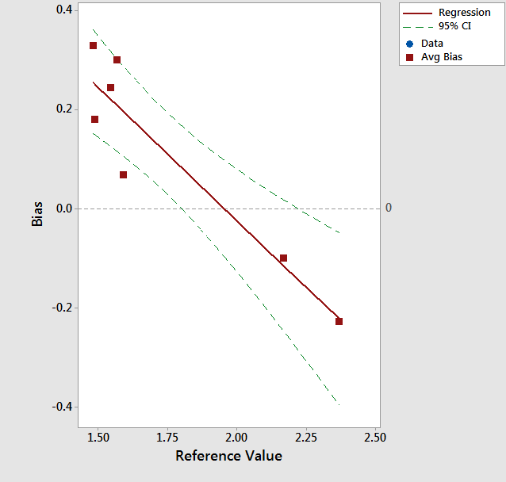

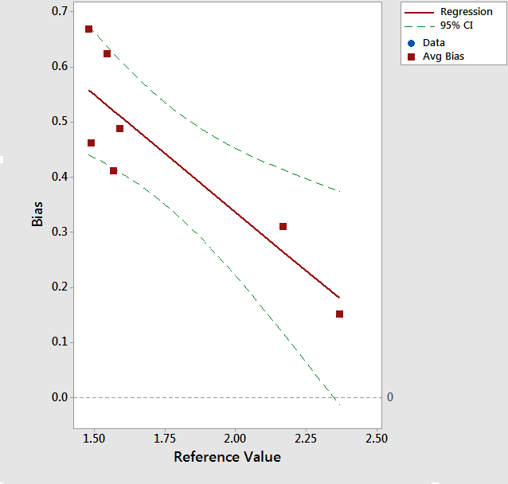

By rearrangement of the aforementioned definitions of bias, Eqs. 1 and 2:

$m_1 = ref + bias_1$ [Eq. 5]  
$m_2 = ref + bias_2$. [Eq. 6]

$m_1 = ref + bias_1 = ref + (1.1885 - 0.4258(ref)) = 1.1885 + 0.5742(ref)$ [Eq. 7] $m_2 = ref + bias_2 = ref + (1.0542 - 0.5388(ref)) = 1.0542 + 0.4612(ref)$. [Eq. 8]

Recall that the purpose of the model was to be able to predict the *ref* value based on the readings of *m1* and *m2*. All that is needed is to rearrange equations 7 and 8 to

$ref = \frac{m_{1} - 1.1885}{0.5742} = -2.0698 + 1.7412(m_1)$ [Eq. 9]  
$ref = \frac{m_{2} - 1.0542}{0.4612} = -2.2858 + 2.1683(m_2)$. [Eq. 10]

Note that the linear coefficients from the Gage analysis differ greatly from those from the OLS regression from Table 3:

$ref = -1.5106 + 1.4862(m_1)$ [Eq. 11]  
$ref = -1.5799 + 1.7885(m_2)$. [Eq. 12]